# Pacific Salmon SAR & SAS Estimator

Background

This script uses WDFW hatchery coded wire tag (CWT) release and return data to fit run-specific smolt-adult return (SAR) and smolt-adult-survival (SAS) models for Pacific salmon species. The first chunk below loads libraries, sets directories, and sources any functions required for the analysis. A table is generated that displays species- and system-specific location_code information for the parameters set in the YAML header, including hatchery_location_codes, release_location_codes, and stock_location_codes for data to be used in SAR/SAS calculation. This table is based on a metadata ruleset constructed by the developers, and new queries will require additions to this ruleset for smooth data processing and model fitting.

This chunk pulls CWT-based release and recovery data from the Pacific States Marine Fisheries Commission’s (PSMFC) Regional Marking Information System (RMIS) database for the species and hatchery stock set by the user at the top of this script. Release and return data are categorized by release size, release stage, release location, and are uniquely identified by coded-wire-tag codes. The release data are pulled first and length-weight data associated with those releases are used to determine stage-at-release.

To ensure all data employed in SAR/SAS calculations are smolt-release data, the script categorizes releases by stage using a mixture of information reported in the literature and RMIS data queried by the user. Quinn (2018) reports length-at-smolt (mm) by species in Table 15.1, which summarizes data from 218 published and unpublished reports. We use these reported values to inform a release stage designation, where the avg_length and avg_weight fields queried from RMIS by the user are fit to an exponential model and the model fit is used to predict weight-at-smolt. This weight-at-smolt is then used to classify release stages, currently implemented as “smolt” if they are larger than the threshold size calculated or “fry_parr” if smaller than it. Given the query-specific nature of this analysis, if program- or system-specific data on size-at-smolt were available, these data could be used directly to inform release_stage classifications.

The CWT tag codes retained in the release data after filtering are then used to iteratively pull recovery data by tag code. The estimated number of recoveries (number_cwt_estimated) is reported by tag_code, so only grouped data are available. These data are aggregated by tag_code and rearing treatments of interest (e.g., size-at-release, release month, release julian day, etc.). Release year and recovery year are used to calculate age-at-recovery, and this age is used to filter the data for adults (e.g., age-3+ in Region 5). Together, these filtered release and recovery data are used to calculate fate-specific SARs below.

**Tab 1**

Table 1: Parameter values set in the YAML header defining which data are being pulled from RMIS for calculation of SAR and SAS.

| params | value |
| --- | --- |
| system | r5_lewis |
| species | 1 |
| run | 1 |
| start_yr | 2010 |
| end_yr | 2020 |

**Tab 2**

| species | run | loc_code | loc_col | name | region | system |
| --- | --- | --- | --- | --- | --- | --- |
| 1 | 1 | 3F42001^^270168^H | hatchery_location_code | LEWIS RIVER HATCHERY | 5 | r5_lewis |
| 2 | 3 | 3F42001^^270168^H | hatchery_location_code | LEWIS RIVER HATCHERY | 5 | r5_lewis |
| 2 | 7 | 3F42001^^270168^H | hatchery_location_code | LEWIS RIVER HATCHERY | 5 | r5_lewis |
| 1 | 3 | 3F42001^^270168^H | hatchery_location_code | LEWIS RIVER HATCHERY | 5 | r5_lewis |
| 3 | 2 | 3F42001^^270168^H | hatchery_location_code | LEWIS RIVER HATCHERY | 5 | r5_lewis |
| 3 | 4 | 3F42001^^270168^H | hatchery_location_code | LEWIS RIVER HATCHERY | 5 | r5_lewis |
| 3 | 4 | 3F42001^^270168^H02 | hatchery_location_code | MERWIN HATCHERY | 5 | r5_lewis |
| 3 | 2 | 3F42001^^270168^H02 | hatchery_location_code | MERWIN HATCHERY | 5 | r5_lewis |
| 3 | 9 | 3F42001^^270168^H02 | hatchery_location_code | MERWIN HATCHERY | 5 | r5_lewis |
| 2 | 3 | 3F42001^^270430^H | hatchery_location_code | SPEELYAI HATCHERY | 5 | r5_lewis |
| 1 | 1 | 3F42001^^270430^H | hatchery_location_code | SPEELYAI HATCHERY | 5 | r5_lewis |
| 2 | 7 | 3F42001^^270430^H | hatchery_location_code | SPEELYAI HATCHERY | 5 | r5_lewis |
| 1 | 3 | 3F42001^^270430^H | hatchery_location_code | SPEELYAI HATCHERY | 5 | r5_lewis |
| 3 | 4 | 3F42001^^270430^H | hatchery_location_code | SPEELYAI HATCHERY | 5 | r5_lewis |
| 3 | 2 | 3F42001^^270430^H | hatchery_location_code | SPEELYAI HATCHERY | 5 | r5_lewis |

**Tab 3**

| species | run | loc_code | loc_col | name | region | system |
| --- | --- | --- | --- | --- | --- | --- |

[interactive chart not shown]

Figure 1: Length-weight relationship used to determine weight-at-smolt via reported lenght-at-smolt (Quinn, 2018). The red-dashed vertical line shows the species-specific size used for the weight-at-smolt conversion. Facets are split by run.

References

Independent Scientific Advisory Board (ISAB). 2025. Challenges and opportunities for improved estimation, interpretation, and use of smolt-to-adult return (SAR) and survival (SAS) metrics for salmon and steelhead in the Columbia River Basin. Report ISAB 2025-1. Northwest Power and Conservation Council, Portland, Oregon.

Quinn, T.P. 2018. The behavior and ecology of Pacific salmon and trout. Second Edition. University of Washington Press. ISBN: 9780295743332.

Smolt-adult-return (SAR)

Smolt-adult-return is calculated for each categorized fate (hatchery, fishery, and spawning ground) of paired release-recovery data. Below, fate is categorized based on fishery coding, and then fate-specific SARs are reported. These fate-specific SARs are then used below to: (1) fit predictive SAR models, and (2) calculate smolt-adult-survival (SAS). Fate is determined by the fishery coding reported for each recovery. Fishery codes range from 10-99, with some additional codes supplied for high seas fishery categories (800-812). We designate troll (10-19), net & seine (20-29), aboriginal (30-39), sport (40-49), treaty subsitence (56), test (60-69), and high seas (80-89, 800, 802-805, 812) fisheries recoveries as ‘fishery’ fates. In addition, we designate hatchery (50), fish trap (52), broodstock collections (53), and mixed broodstock collection/hatchery returns (57) recoveies as ‘hatchery’ fates, and we designate spawning ground (54) recoveries as ‘spawngr’ fates.

[figure not shown]

Figure 2: Smolt-adult return calculated collectively across brood year released and recovery fate.

**Tab 1**

Table 4: Recovery locations associated with a ‘hatchery’ fate in the filtered data, and the number of estimated recoveries (number_cwt_estimated) reported for each recovery location.

| recovery_location_code | name | latitude | longitude | psc_region | number_cwt_estimated |
| --- | --- | --- | --- | --- | --- |
| 3F42001^^270168^H | LEWIS RIVER HATCHERY | 45.9370 | -122.6165 | LOCR | 4532.18 |
| 3F42001^^270168^R03 | MERWIN DAM FCF | 45.9570 | -122.5561 | LOCR | 173.11 |
| 3F42001^^270002^H | KALAMA FALLS HATCHERY | 46.0160 | -122.7336 | LOCR | 43.43 |
| 3F42001^^270339^R | CEDAR CR 27.0339 | 45.9365 | -122.6174 | LOCR | 13.00 |
| 3F42001^^260002^H02 | COWLITZ SALMON HATCHERY | 46.5113 | -122.6293 | LOCR | 11.25 |
| 3F42001^^270002^H03 | MODROW TRAP | 46.0447 | -122.8387 | LOCR | 3.00 |
| 3F42001^^270339^R10 | CEDAR CR TRAP | 45.9365 | -122.6174 | LOCR | 3.00 |
| 3F42001^^360126^H | PRIEST RAPIDS HATCHERY | 46.6486 | -119.8967 | UPCR | 2.02 |
| 5F33328^^H28^^^^21 | SOUTH SANTIAM HATCH | NA | NA | LOCR | 1.01 |

**Tab 2**

Table 5: Recovery locations associated with a ‘spawngr’ fate in the filtered data, and the number of estimated recoveries (number_cwt_estimated) reported for each recovery location.

| recovery_location_code | name | latitude | longitude | psc_region | number_cwt_estimated |
| --- | --- | --- | --- | --- | --- |
| 3F42001^^270168^R | LEWIS R 27.0168 | 45.8504 | -122.7824 | LOCR | 422.34 |
| 3F42001^^270168^R01 | LEWIS R -NF 27.0168 | 45.8504 | -122.7824 | LOCR | 51.36 |

**Tab 3**

Table 6: Recovery locations associated with a ‘fishery’ fate in the filtered data, and the number of estimated recoveries (number_cwt_estimated) reported for each recovery location.

| recovery_location_code | name | latitude | longitude | psc_region | number_cwt_estimated |
| --- | --- | --- | --- | --- | --- |
| 3F42001^^270168^R01 | LEWIS R -NF 27.0168 | 45.8504 | -122.7824 | LOCR | 149.65 |
| 2MN06P101^^^^^^^000 | NTR P101-000 | NA | NA | NA | 48.10 |
| 5F33207^^R7^^^^^13 | YOUNGS BAY NET ZONE 7 | 46.1917 | -123.8833 | LOCR | 46.90 |
| 3F42001^^270002^R | KALAMA R 27.0002 | 46.0338 | -122.8746 | LOCR | 39.24 |
| 5F33271^^R71^^^^13 | TONGUE POINT ZONE 71 | NA | NA | LOCR | 28.48 |
| 5F33307^^R4^^^^^14 | WILLAMETTE R LWR BTS | NA | NA | LOCR | 19.94 |
| 1M2PW212 | AK M 2 PW 212 | NA | NA | CEAK | 19.54 |
| 5F33203^^R209^^^12 | COL R OR SPORT SEC 9 | NA | NA | LOCR | 18.95 |
| 2MN06P142^^^^^^^000 | NTR P142-000 | NA | NA | NA | 17.41 |
| 5F33203^^R110^^^12 | COL R WA SPORT SEC 10 | NA | NA | LOCR | 17.15 |
| 3M32202 | MARINE AREA 2 | NA | NA | GRAY | 16.05 |
| 1M1NW113^41 | AK M 1 NW 113-41 | NA | NA | SEAK | 14.87 |
| 1M1NW154 | AK M 1 NW 154 | NA | NA | SEAK | 14.87 |
| 3M32303 | MARINE AREA 3 | NA | NA | NWC | 14.41 |
| 5F33203^^R205^^^12 | COL R OR SPORT SEC 5 | NA | NA | LOCR | 11.94 |
| 5F33203^^R106^^^12 | COL R WA SEC 6 | NA | NA | LOCR | 10.50 |
| 1M1SW152 | AK M 1 SW 152 | NA | NA | SEAK | 9.38 |
| 1M1NW | AK M 1 NW | NA | NA | SEAK | 8.54 |
| 5F33203^^R204^^^12 | COL R OR SPORT SEC 4 | NA | NA | LOCR | 8.34 |
| 2MSSVP123 | SWVISPT P123 | NA | NA | NA | 7.92 |
| 5F33203^^R203^^^12 | COL R OR SPORT SEC 3 | NA | NA | LOCR | 7.87 |
| 5F33203^^R109^^^12 | COL R WA SPORT SEC 9 | NA | NA | LOCR | 7.64 |
| 3F42001^^260002^R | COWLITZ R 26.0002 | 46.0956 | -122.9155 | LOCR | 6.35 |
| 5F33209^^R3^^^^^13 | COL R ZONE 3 NET | NA | NA | LOCR | 6.09 |
| 5F33203^^R104^^^12 | COL R WA SEC 4 | NA | NA | LOCR | 5.69 |
| 1M1NW113^91 | AK M 1 NW 113-91 | NA | NA | SEAK | 4.96 |
| 2MS01P127^^^^^^^000 | NWTR P127-000 | NA | NA | NA | 4.84 |
| 1M1SW104^4007^^MS | AK M 1 SW 104-4007 MS | NA | NA | SEAK | 4.76 |
| 6MO^^^^^^PAPR | PT.ARENA-PT.REYES | NA | NA | CAGN | 4.62 |
| 2MS01M403^^^^^^^000 | NWTR M403-000 | NA | NA | NA | 4.44 |
| 3M32404 | MARINE AREA 4 | NA | NA | NWC | 4.42 |
| 2MSNGP014SANG^IS^03 | NSGSPTSANG IS(14-3) | 49.4261 | -124.1992 | NA | 4.31 |
| 2MS02M111^^^^^^^000 | SWTR M111-000 | NA | NA | NA | 4.20 |
| 2MN06P001^^^^^^^000 | NTR P001-000 | NA | NA | NA | 4.18 |
| 5F33203^^R103^^^12 | COL R WA SPORT SEC 3 | NA | NA | LOCR | 4.10 |
| 1M1NW113^61 | AK M 1 NW 113-61 | NA | NA | SEAK | 4.08 |
| 5F33209^^R4^^^^^13 | COL R ZONE 4 NET | NA | NA | LOCR | 4.05 |
| 1M1NW113^31 | AK M 1 NW 113-31 | NA | NA | SEAK | 3.95 |
| 1M1NW157 | AK M 1 NW 157 | NA | NA | SEAK | 3.95 |
| 1M1NW113^45 | AK M 1 NW 113-45 | NA | NA | SEAK | 3.70 |
| 2MS5SP024^^^^^^^000 | 5NWCVIS P024-000 | NA | NA | NA | 3.61 |
| 5F33274^^R74^^^^13 | BLIND SLOUGH ZONE 74 | NA | NA | LOCR | 3.38 |
| 5F33307^^R3^^^^^14 | WILLAMETTE R (MIDRIV | NA | NA | LOCR | 3.31 |
| 1M1NE109^61 | AK M 1 NE 109-61 | NA | NA | SEAK | 3.27 |
| 1M1NE109^10 | AK M 1 NE 109-10 | NA | NA | SEAK | 3.17 |
| 7M3^^^^N^^^^W^^^630 | HIGH SEAS 3 N W US 630 | NA | NA | NA | 3.00 |
| 5F33220^^R20^^^^15 | NEW TEST ZONE 2 | NA | NA | LOCR | 3.00 |
| 1M1SWSASO | AK M 1 SW SASO | NA | NA | SEAK | 2.79 |
| 1M1NW116^11 | AK M 1 NW 116-11 | NA | NA | SEAK | 2.63 |
| 7M1^^47N^125W | HIGH SEAS 1 47N 125W | 47.0000 | -125.0000 | NA | 2.62 |
| 1M1NW113^22 | AK M 1 NW 113-22 | NA | NA | SEAK | 2.40 |
| 2MS02P123^^^^^^^000 | SWTR P123-000 | NA | NA | NA | 2.40 |
| 5F33209^^R2^^^^^13 | COL R ZONE 2 NET | NA | NA | LOCR | 2.25 |
| 3M42001^^A | 1A (BUOY10 - BRIDGE) | NA | NA | LOCR | 2.04 |
| 5F33283^^R83^^^^15 | COL R ZONE 83 CATHLAMET | NA | NA | LOCR | 2.00 |
| 7M3^^^^N^^^^W^^^610 | HIGH SEAS 3 N W US 610 | NA | NA | NA | 2.00 |
| 2MS02M23B^^^^^^^000 | SWTR M23B-000 | NA | NA | NA | 1.94 |
| 2MS02M401^^^^^^^000 | SWTR M401-000 | NA | NA | NA | 1.81 |
| 3M32101 | MARINE AREA 1 | NA | NA | WILP | 1.43 |
| 7M3^^^^N^^^^W^^^620 | HIGH SEAS 3 N W US 620 | NA | NA | NA | 1.00 |
| 2MS5SP124^^^^^^^000 | 5NWCVIS P124-000 | NA | NA | NA | 1.00 |
| 1M1 | AK M 1 | NA | NA | SEAK | 0.00 |
| 1M4KD | AK M 4 KD | NA | NA | WEAK | 0.00 |
| 1M2LC241^^^18^^MB | AK M 2 LC 241- 18 MB | NA | NA | CEAK | 0.00 |

**Tab A**

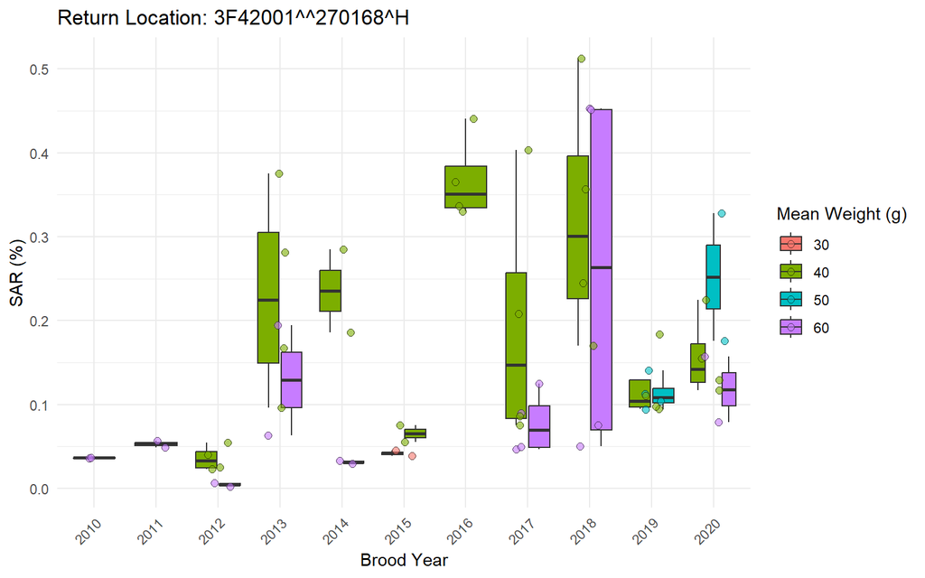

Figure 3: Smolt-adult return calcualted from the raw release and return data across brood years and mean weight release groups.

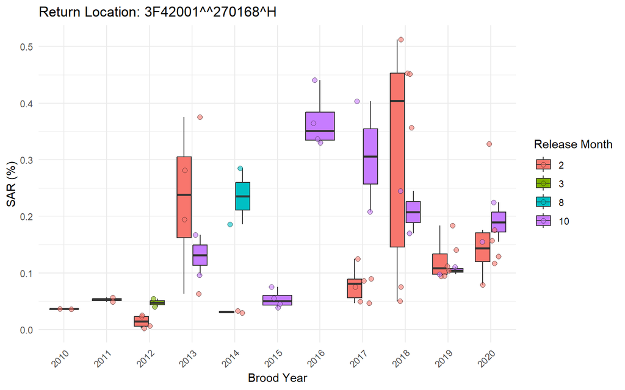

Figure 4: Smolt-adult return calcualted from the raw release and return data across brood years and release month.

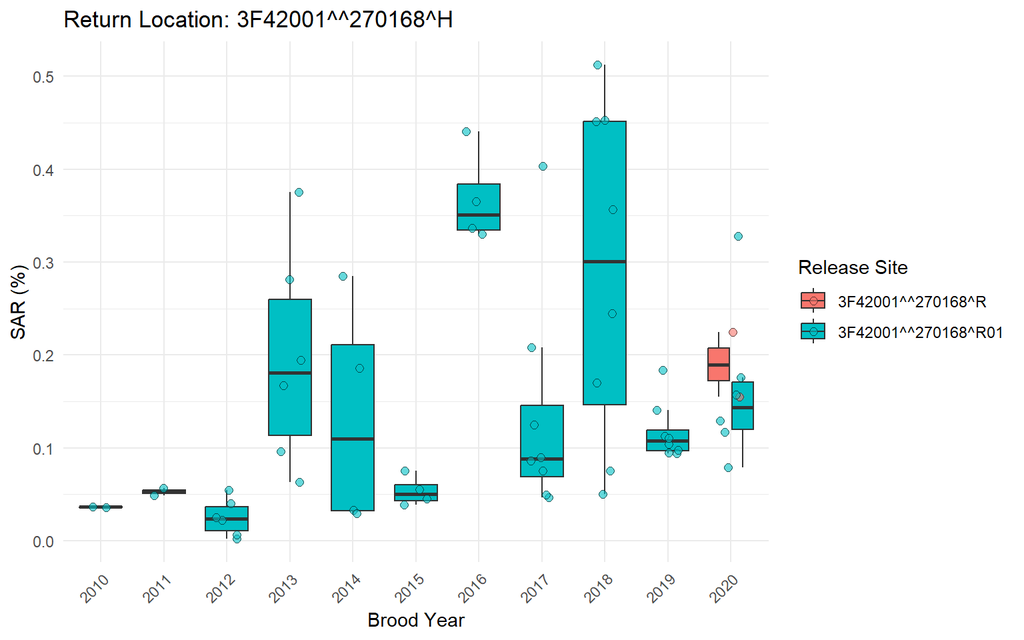

Figure 5: Smolt-adult return calcualted from the raw release and return data across brood years and release sites.

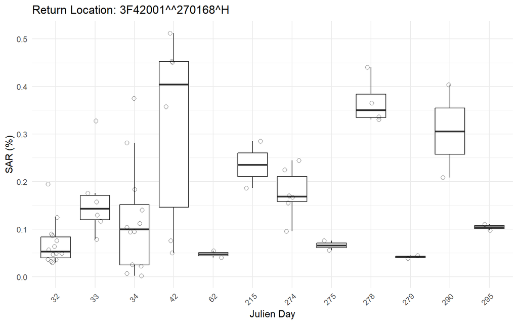

Figure 6: Smolt-adult return calcualted from the raw release and return data across brood years and julian days.

**Tab B**

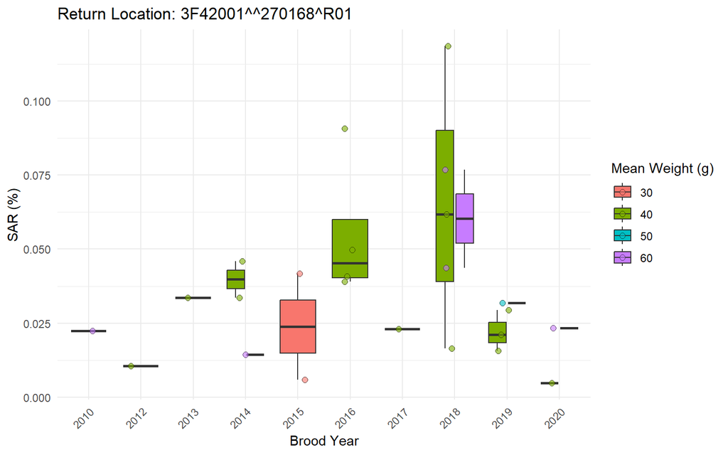

Figure 7: Smolt-adult return calcualted from the raw release and return data across brood years and mean weight release groups.

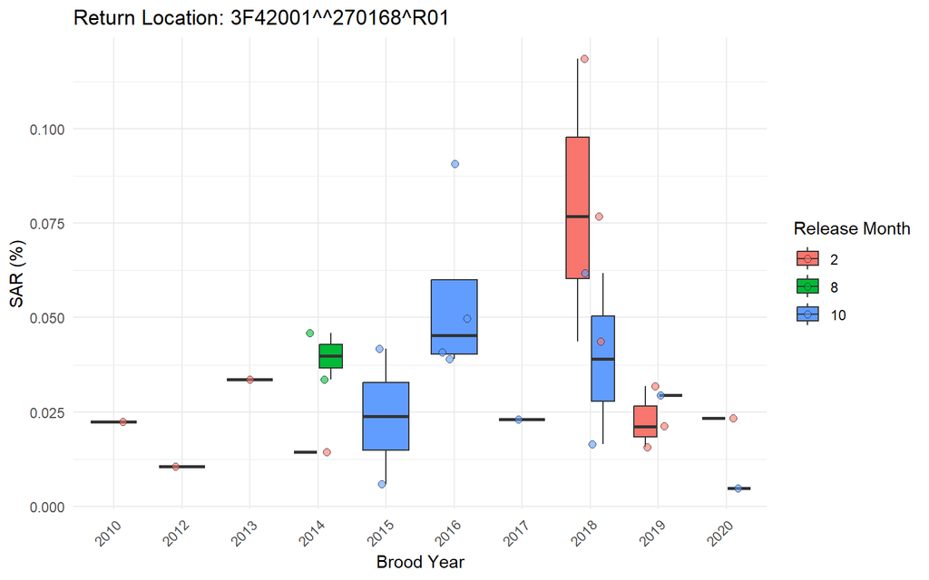

Figure 8: Smolt-adult return calcualted from the raw release and return data across brood years and release month.

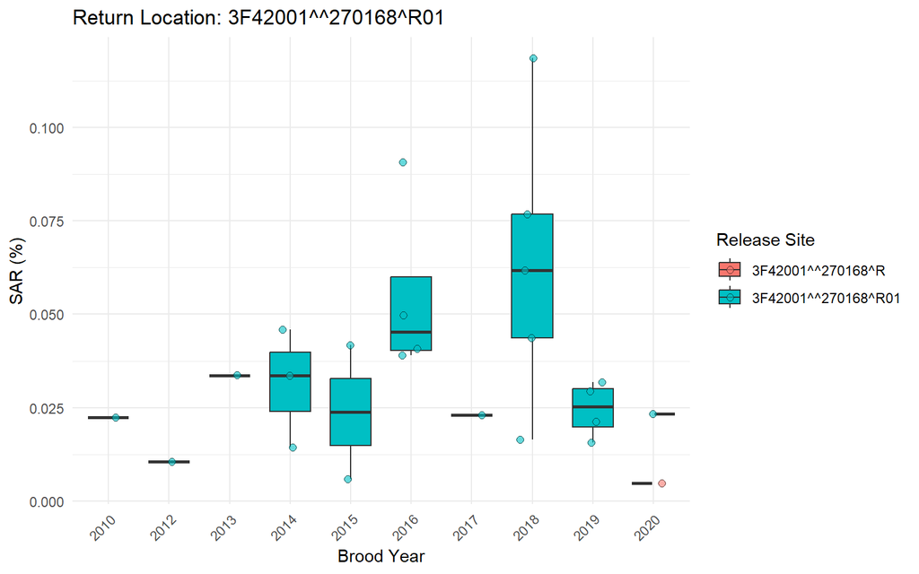

Figure 9: Smolt-adult return calcualted from the raw release and return data across brood years and release sites.

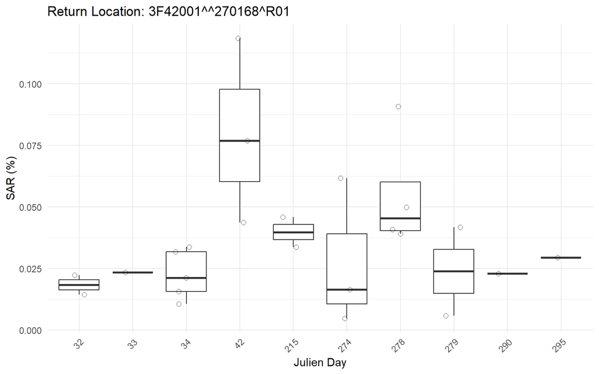

Figure 10: Smolt-adult return calcualted from the raw release and return data across brood years and julian days.

**Tab C**

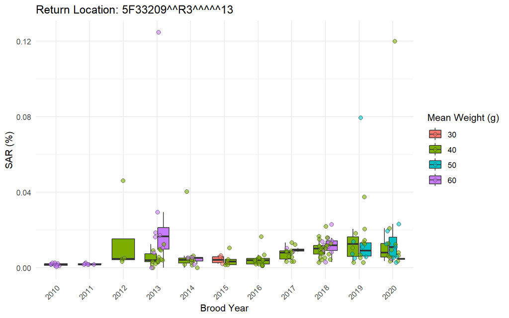

Figure 11: Smolt-adult return calcualted from the raw release and return data across brood years and mean weight release groups.

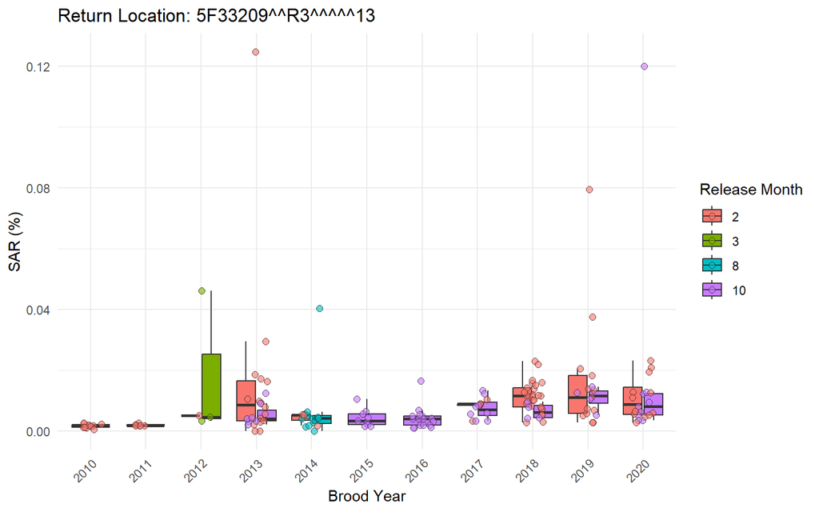

Figure 12: Smolt-adult return calcualted from the raw release and return data across brood years and release month.

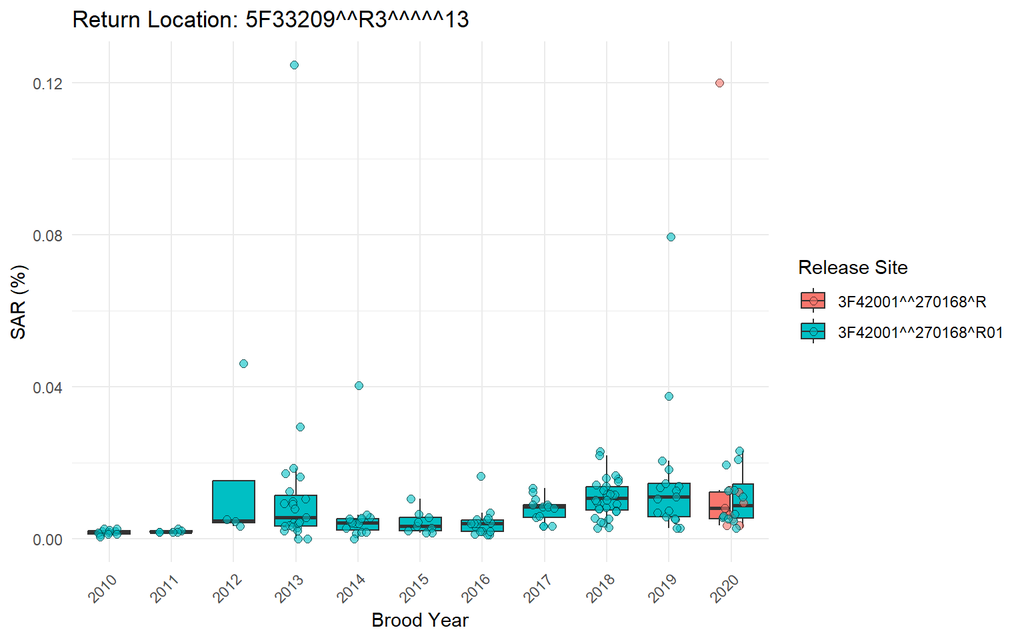

Figure 13: Smolt-adult return calcualted from the raw release and return data across brood years and release sites.

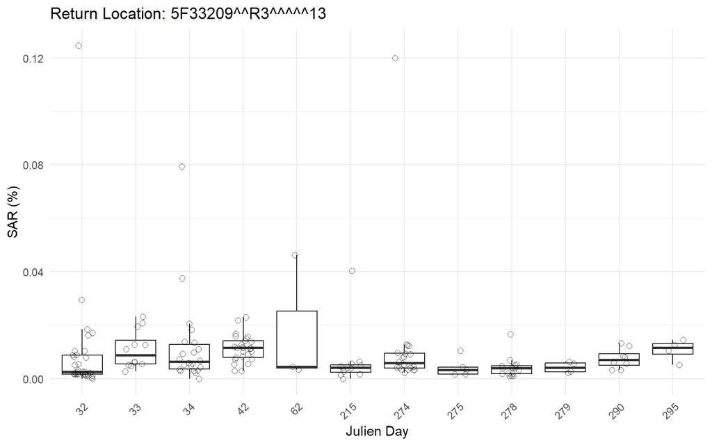

Figure 14: Smolt-adult return calcualted from the raw release and return data across brood years and julian days.

**Tab A**

Table 7: Smolt-adult return calculated across brood years, mean weight-at-release, and time at release.

| species | release_location_code | recovery_location_code | month | jday | avg_weight | event_released | sar |
| --- | --- | --- | --- | --- | --- | --- | --- |
| **2010** |  |  |  |  |  |  |  |
| 1 | 3F42001^^270168^R01 | 3F42001^^270168^H | 2 | 32 | 60 | 229502 | 0.0003582 |
| 1 | 3F42001^^270168^R01 | 3F42001^^270168^H | 2 | 32 | 60 | 211944 | 0.0003692 |
| **2011** |  |  |  |  |  |  |  |
| 1 | 3F42001^^270168^R01 | 3F42001^^270168^H | 2 | 32 | 60 | 136699 | 0.0004869 |
| 1 | 3F42001^^270168^R01 | 3F42001^^270168^H | 2 | 32 | 60 | 133351 | 0.0005671 |
| **2012** |  |  |  |  |  |  |  |
| 1 | 3F42001^^270168^R01 | 3F42001^^270168^H | 2 | 34 | 40 | 44430 | 0.0002262 |
| 1 | 3F42001^^270168^R01 | 3F42001^^270168^H | 2 | 34 | 40 | 43892 | 0.0002515 |
| 1 | 3F42001^^270168^R01 | 3F42001^^270168^H | 2 | 34 | 60 | 44679 | 0.0000224 |
| 1 | 3F42001^^270168^R01 | 3F42001^^270168^H | 2 | 34 | 60 | 44554 | 0.0000676 |
| 1 | 3F42001^^270168^R01 | 3F42001^^270168^H | 3 | 62 | 40 | 42111 | 0.0004049 |
| 1 | 3F42001^^270168^R01 | 3F42001^^270168^H | 3 | 62 | 40 | 42172 | 0.0005470 |
| **2013** |  |  |  |  |  |  |  |
| 1 | 3F42001^^270168^R01 | 3F42001^^270168^H | 2 | 34 | 40 | 47259 | 0.0028153 |
| 1 | 3F42001^^270168^R01 | 3F42001^^270168^H | 2 | 34 | 40 | 47136 | 0.0037551 |
| 1 | 3F42001^^270168^R01 | 3F42001^^270168^H | 2 | 32 | 60 | 25220 | 0.0006344 |
| 1 | 3F42001^^270168^R01 | 3F42001^^270168^H | 2 | 32 | 60 | 25166 | 0.0019479 |
| 1 | 3F42001^^270168^R01 | 3F42001^^270168^H | 10 | 274 | 40 | 51109 | 0.0009587 |
| 1 | 3F42001^^270168^R01 | 3F42001^^270168^H | 10 | 274 | 40 | 50777 | 0.0016742 |
| **2014** |  |  |  |  |  |  |  |
| 1 | 3F42001^^270168^R01 | 3F42001^^270168^H | 2 | 32 | 60 | 58044 | 0.0003284 |
| 1 | 3F42001^^270168^R01 | 3F42001^^270168^H | 2 | 32 | 60 | 58276 | 0.0002934 |
| 1 | 3F42001^^270168^R01 | 3F42001^^270168^H | 8 | 215 | 40 | 73182 | 0.0018621 |
| 1 | 3F42001^^270168^R01 | 3F42001^^270168^H | 8 | 215 | 40 | 72782 | 0.0028481 |
| **2015** |  |  |  |  |  |  |  |
| 1 | 3F42001^^270168^R01 | 3F42001^^270168^H | 10 | 279 | 30 | 46852 | 0.0003865 |
| 1 | 3F42001^^270168^R01 | 3F42001^^270168^H | 10 | 279 | 30 | 47223 | 0.0004489 |
| 1 | 3F42001^^270168^R01 | 3F42001^^270168^H | 10 | 275 | 40 | 61567 | 0.0005560 |
| 1 | 3F42001^^270168^R01 | 3F42001^^270168^H | 10 | 275 | 40 | 61322 | 0.0007557 |
| **2016** |  |  |  |  |  |  |  |
| 1 | 3F42001^^270168^R01 | 3F42001^^270168^H | 10 | 278 | 40 | 47929 | 0.0033018 |
| 1 | 3F42001^^270168^R01 | 3F42001^^270168^H | 10 | 278 | 40 | 47929 | 0.0033635 |
| 1 | 3F42001^^270168^R01 | 3F42001^^270168^H | 10 | 278 | 40 | 99317 | 0.0036500 |
| 1 | 3F42001^^270168^R01 | 3F42001^^270168^H | 10 | 278 | 40 | 99317 | 0.0044069 |
| **2017** |  |  |  |  |  |  |  |
| 1 | 3F42001^^270168^R01 | 3F42001^^270168^H | 2 | 32 | 40 | 37336 | 0.0008619 |
| 1 | 3F42001^^270168^R01 | 3F42001^^270168^H | 2 | 32 | 40 | 37261 | 0.0007547 |
| 1 | 3F42001^^270168^R01 | 3F42001^^270168^H | 2 | 32 | 60 | 36724 | 0.0004651 |
| 1 | 3F42001^^270168^R01 | 3F42001^^270168^H | 2 | 32 | 60 | 36566 | 0.0004944 |
| 1 | 3F42001^^270168^R01 | 3F42001^^270168^H | 2 | 32 | 60 | 37807 | 0.0012495 |
| 1 | 3F42001^^270168^R01 | 3F42001^^270168^H | 2 | 32 | 60 | 38061 | 0.0008983 |
| 1 | 3F42001^^270168^R01 | 3F42001^^270168^H | 10 | 290 | 40 | 37733 | 0.0020823 |
| 1 | 3F42001^^270168^R01 | 3F42001^^270168^H | 10 | 290 | 40 | 37909 | 0.0040355 |
| **2018** |  |  |  |  |  |  |  |
| 1 | 3F42001^^270168^R01 | 3F42001^^270168^H | 2 | 42 | 40 | 35655 | 0.0035706 |
| 1 | 3F42001^^270168^R01 | 3F42001^^270168^H | 2 | 42 | 40 | 35585 | 0.0051232 |
| 1 | 3F42001^^270168^R01 | 3F42001^^270168^H | 2 | 42 | 60 | 34049 | 0.0045320 |
| 1 | 3F42001^^270168^R01 | 3F42001^^270168^H | 2 | 42 | 60 | 35688 | 0.0005049 |
| 1 | 3F42001^^270168^R01 | 3F42001^^270168^H | 2 | 42 | 60 | 33981 | 0.0045119 |
| 1 | 3F42001^^270168^R01 | 3F42001^^270168^H | 2 | 42 | 60 | 35835 | 0.0007562 |
| 1 | 3F42001^^270168^R01 | 3F42001^^270168^H | 10 | 274 | 40 | 32997 | 0.0017017 |
| 1 | 3F42001^^270168^R01 | 3F42001^^270168^H | 10 | 274 | 40 | 33193 | 0.0024445 |
| **2019** |  |  |  |  |  |  |  |
| 1 | 3F42001^^270168^R01 | 3F42001^^270168^H | 2 | 34 | 40 | 34886 | 0.0009500 |
| 1 | 3F42001^^270168^R01 | 3F42001^^270168^H | 2 | 34 | 40 | 35077 | 0.0018360 |
| 1 | 3F42001^^270168^R01 | 3F42001^^270168^H | 2 | 34 | 50 | 35306 | 0.0009404 |
| 1 | 3F42001^^270168^R01 | 3F42001^^270168^H | 2 | 34 | 50 | 33995 | 0.0011231 |
| 1 | 3F42001^^270168^R01 | 3F42001^^270168^H | 2 | 34 | 50 | 35621 | 0.0010435 |
| 1 | 3F42001^^270168^R01 | 3F42001^^270168^H | 2 | 34 | 50 | 34339 | 0.0014060 |
| 1 | 3F42001^^270168^R01 | 3F42001^^270168^H | 10 | 295 | 40 | 37087 | 0.0009772 |
| 1 | 3F42001^^270168^R01 | 3F42001^^270168^H | 10 | 295 | 40 | 37210 | 0.0011083 |
| **2020** |  |  |  |  |  |  |  |
| 1 | 3F42001^^270168^R01 | 3F42001^^270168^H | 2 | 33 | 40 | 36749 | 0.0011701 |
| 1 | 3F42001^^270168^R01 | 3F42001^^270168^H | 2 | 33 | 40 | 37096 | 0.0012939 |
| 1 | 3F42001^^270168^R01 | 3F42001^^270168^H | 2 | 33 | 50 | 36983 | 0.0017578 |
| 1 | 3F42001^^270168^R01 | 3F42001^^270168^H | 2 | 33 | 50 | 36906 | 0.0032786 |
| 1 | 3F42001^^270168^R01 | 3F42001^^270168^H | 2 | 33 | 60 | 31832 | 0.0015707 |
| 1 | 3F42001^^270168^R01 | 3F42001^^270168^H | 2 | 33 | 60 | 31724 | 0.0007880 |
| 1 | 3F42001^^270168^R | 3F42001^^270168^H | 10 | 274 | 40 | 38327 | 0.0022441 |
| 1 | 3F42001^^270168^R | 3F42001^^270168^H | 10 | 274 | 40 | 37378 | 0.0015520 |

**Tab B**

Table 8: Smolt-adult return calculated across brood years, mean weight-at-release, and time at release.

| species | release_location_code | recovery_location_code | month | jday | avg_weight | event_released | sar |
| --- | --- | --- | --- | --- | --- | --- | --- |
| **2010** |  |  |  |  |  |  |  |
| 1 | 3F42001^^270168^R01 | 3F42001^^270168^R01 | 2 | 32 | 60 | 229502 | 0.0002238 |
| **2012** |  |  |  |  |  |  |  |
| 1 | 3F42001^^270168^R01 | 3F42001^^270168^R | 2 | 34 | 40 | 44430 | 0.0001060 |
| **2013** |  |  |  |  |  |  |  |
| 1 | 3F42001^^270168^R01 | 3F42001^^270168^R | 2 | 34 | 40 | 47259 | 0.0003367 |
| **2014** |  |  |  |  |  |  |  |
| 1 | 3F42001^^270168^R01 | 3F42001^^270168^R | 2 | 32 | 60 | 58276 | 0.0001433 |
| 1 | 3F42001^^270168^R01 | 3F42001^^270168^R | 8 | 215 | 40 | 73182 | 0.0003364 |
| 1 | 3F42001^^270168^R01 | 3F42001^^270168^R | 8 | 215 | 40 | 72782 | 0.0004589 |
| **2015** |  |  |  |  |  |  |  |
| 1 | 3F42001^^270168^R01 | 3F42001^^270168^R | 10 | 279 | 30 | 46852 | 0.0004179 |
| 1 | 3F42001^^270168^R01 | 3F42001^^270168^R | 10 | 279 | 30 | 47223 | 0.0000582 |
| **2016** |  |  |  |  |  |  |  |
| 1 | 3F42001^^270168^R01 | 3F42001^^270168^R | 10 | 278 | 40 | 47929 | 0.0009076 |
| 1 | 3F42001^^270168^R01 | 3F42001^^270168^R | 10 | 278 | 40 | 47929 | 0.0004085 |
| 1 | 3F42001^^270168^R01 | 3F42001^^270168^R | 10 | 278 | 40 | 99317 | 0.0003900 |
| 1 | 3F42001^^270168^R01 | 3F42001^^270168^R | 10 | 278 | 40 | 99317 | 0.0004980 |
| **2017** |  |  |  |  |  |  |  |
| 1 | 3F42001^^270168^R01 | 3F42001^^270168^R | 10 | 290 | 40 | 37733 | 0.0002300 |
| **2018** |  |  |  |  |  |  |  |
| 1 | 3F42001^^270168^R01 | 3F42001^^270168^R | 2 | 42 | 40 | 35585 | 0.0011853 |
| 1 | 3F42001^^270168^R01 | 3F42001^^270168^R | 2 | 42 | 60 | 34049 | 0.0004373 |
| 1 | 3F42001^^270168^R01 | 3F42001^^270168^R | 2 | 42 | 60 | 33981 | 0.0007687 |
| 1 | 3F42001^^270168^R01 | 3F42001^^270168^R | 10 | 274 | 40 | 32997 | 0.0006170 |
| 1 | 3F42001^^270168^R01 | 3F42001^^270168^R | 10 | 274 | 40 | 33193 | 0.0001648 |
| **2019** |  |  |  |  |  |  |  |
| 1 | 3F42001^^270168^R01 | 3F42001^^270168^R | 2 | 34 | 40 | 34886 | 0.0001568 |
| 1 | 3F42001^^270168^R01 | 3F42001^^270168^R | 2 | 34 | 40 | 35077 | 0.0002118 |
| 1 | 3F42001^^270168^R01 | 3F42001^^270168^R | 2 | 34 | 50 | 34339 | 0.0003186 |
| 1 | 3F42001^^270168^R01 | 3F42001^^270168^R | 10 | 295 | 40 | 37210 | 0.0002940 |
| **2020** |  |  |  |  |  |  |  |
| 1 | 3F42001^^270168^R01 | 3F42001^^270168^R | 2 | 33 | 60 | 31832 | 0.0002334 |
| 1 | 3F42001^^270168^R | 3F42001^^270168^R | 10 | 274 | 40 | 38327 | 0.0000480 |

**Tab C**

Table 9: Smolt-adult return calculated across brood years, mean weight-at-release, and time at release.

| species | release_location_code | recovery_location_code | month | jday | avg_weight | event_released | sar |
| --- | --- | --- | --- | --- | --- | --- | --- |
| **2010** |  |  |  |  |  |  |  |
| 1 | 3F42001^^270168^R01 | 5F33209^^R3^^^^^13 | 2 | 32 | 60 | 229502 | 0.0000096 |
| 1 | 3F42001^^270168^R01 | 5F33209^^R4^^^^^13 | 2 | 32 | 60 | 229502 | 0.0000176 |
| 1 | 3F42001^^270168^R01 | 5F33203^^R110^^^12 | 2 | 32 | 60 | 229502 | 0.0000183 |
| 1 | 3F42001^^270168^R01 | 5F33203^^R203^^^12 | 2 | 32 | 60 | 229502 | 0.0000183 |
| 1 | 3F42001^^270168^R01 | 5F33203^^R205^^^12 | 2 | 32 | 60 | 229502 | 0.0000261 |
| 1 | 3F42001^^270168^R01 | 1M1NW113^45 | 2 | 32 | 60 | 229502 | 0.0000161 |
| 1 | 3F42001^^270168^R01 | 2MN06P101^^^^^^^000 | 2 | 32 | 60 | 229502 | 0.0000219 |
| 1 | 3F42001^^270168^R01 | 3M32303 | 2 | 32 | 60 | 229502 | 0.0000260 |
| 1 | 3F42001^^270168^R01 | 5F33207^^R7^^^^^13 | 2 | 32 | 60 | 211944 | 0.0000117 |
| 1 | 3F42001^^270168^R01 | 7M1^^47N^125W | 2 | 32 | 60 | 211944 | 0.0000124 |
| 1 | 3F42001^^270168^R01 | 3M32404 | 2 | 32 | 60 | 211944 | 0.0000052 |
| **2011** |  |  |  |  |  |  |  |
| 1 | 3F42001^^270168^R01 | 5F33209^^R2^^^^^13 | 2 | 32 | 60 | 136699 | 0.0000165 |
| 1 | 3F42001^^270168^R01 | 5F33209^^R3^^^^^13 | 2 | 32 | 60 | 136699 | 0.0000165 |
| 1 | 3F42001^^270168^R01 | 5F33307^^R4^^^^^14 | 2 | 32 | 60 | 136699 | 0.0000258 |
| 1 | 3F42001^^270168^R01 | 1M1NW113^41 | 2 | 32 | 60 | 136699 | 0.0000214 |
| 1 | 3F42001^^270168^R01 | 1M1SW152 | 2 | 32 | 60 | 136699 | 0.0000171 |
| 1 | 3F42001^^270168^R01 | 5F33207^^R7^^^^^13 | 2 | 32 | 60 | 133351 | 0.0000166 |
| **2012** |  |  |  |  |  |  |  |
| 1 | 3F42001^^270168^R01 | 2MS01M403^^^^^^^000 | 2 | 34 | 40 | 44430 | 0.0000500 |
| 1 | 3F42001^^270168^R01 | 3F42001^^270168^R01 | 3 | 62 | 40 | 42111 | 0.0004619 |
| 1 | 3F42001^^270168^R01 | 3M32202 | 3 | 62 | 40 | 42111 | 0.0000446 |
| 1 | 3F42001^^270168^R01 | 3M32101 | 3 | 62 | 40 | 42172 | 0.0000339 |
| **2013** |  |  |  |  |  |  |  |
| 1 | 3F42001^^270168^R01 | 5F33207^^R7^^^^^13 | 2 | 34 | 40 | 47259 | 0.0000300 |
| 1 | 3F42001^^270168^R01 | 5F33271^^R71^^^^13 | 2 | 34 | 40 | 47259 | 0.0000561 |
| 1 | 3F42001^^270168^R01 | 7M3^^^^N^^^^W^^^630 | 2 | 34 | 40 | 47259 | 0.0000423 |
| 1 | 3F42001^^270168^R01 | 1M1 | 2 | 34 | 40 | 47259 | 0.0000000 |
| 1 | 3F42001^^270168^R01 | 3M32202 | 2 | 34 | 40 | 47259 | 0.0000925 |

[output cut: 146 more lines]

SAR Model Fit

Smolt-adult survival (SAS) represents the survival of a release group when considering all of their possible fates. The “success” of a program will depend on how well the intended fate of those fish matches up with the observed proportion-at-fate. Here, we take release and return data from above and use these data collectively to calculate SAS as the number of fish that were recovered divided by the number released.

| Component | Term | Estimate | Std Error | t-value | p-value |  |
| --- | --- | --- | --- | --- | --- | --- |
| A. parametric coefficients | (Intercept) | -9.578 | 0.149 | -64.350 | 0.0000 | *** |
|  | fatehatchery | 2.194 | 0.156 | 14.090 | 0.0000 | *** |
|  | fatespawngr | 1.579 | 0.227 | 6.949 | 0.0000 | *** |
| Component | Term | edf | Ref. df | F-value | p-value |  |
| B. smooth terms | s(brood_year) | 7.184 | 10.000 | 8.057 | 0.0000 | *** |
|  | s(avg_weight) | 0.534 | 3.000 | 0.360 | 0.1464 |  |
|  | te(jday,brood_year) | 1.631 | 9.000 | 0.555 | 0.0137 |  |

Signif. codes: 0 <= '***' < 0.001 < '**' < 0.01 < '*' < 0.05  
Adjusted R-squared: 0.866, Deviance explained 0.898  
-REML : -267.272, Scale est: 14.208, N: 67

**Tab 1**

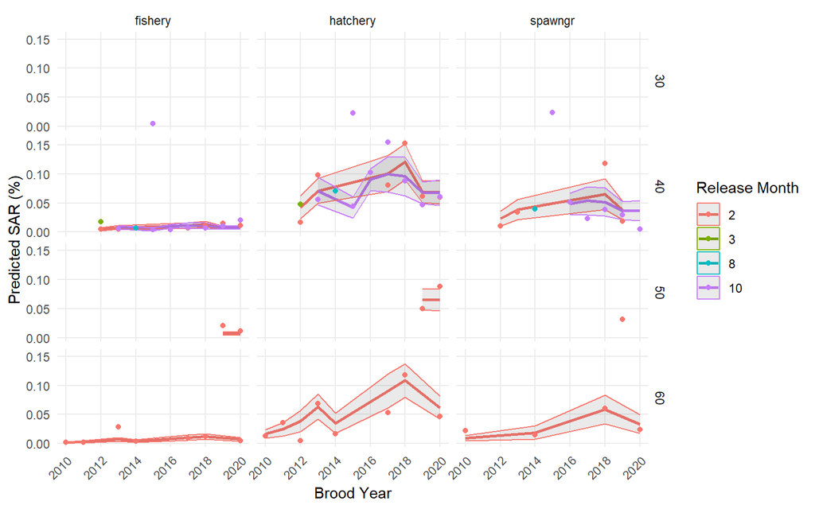

Figure 15: Predicted smolt-adult return generated from the model fit across fate, brood years, mean weight release groups, and release month.

**Tab 2**

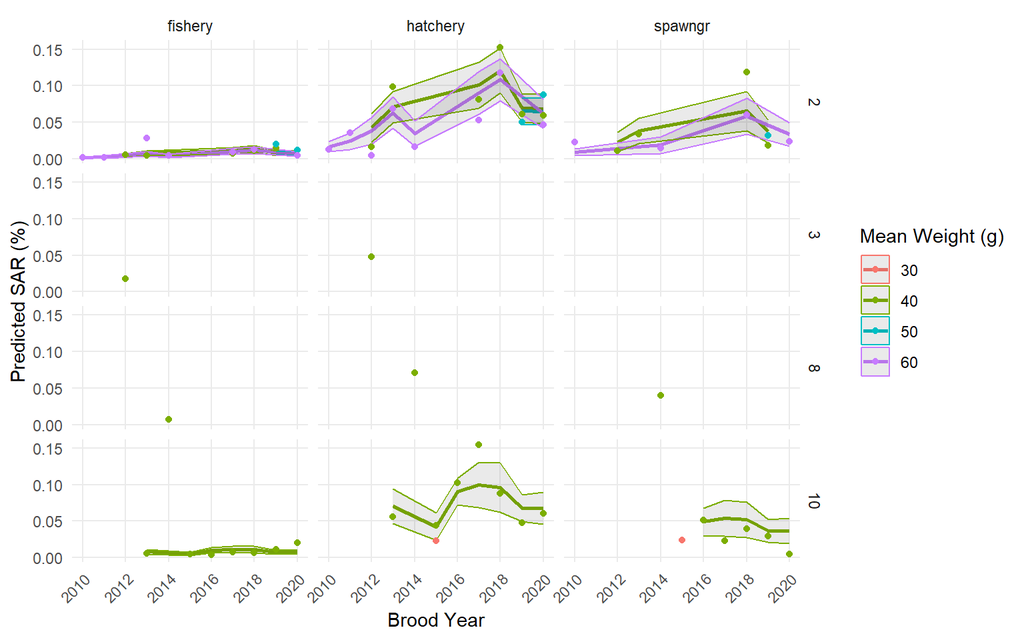

Figure 16: Predicted smolt-adult return generated from the model fit across fate, brood years, mean weight release groups, and release month.

**Tab 3**

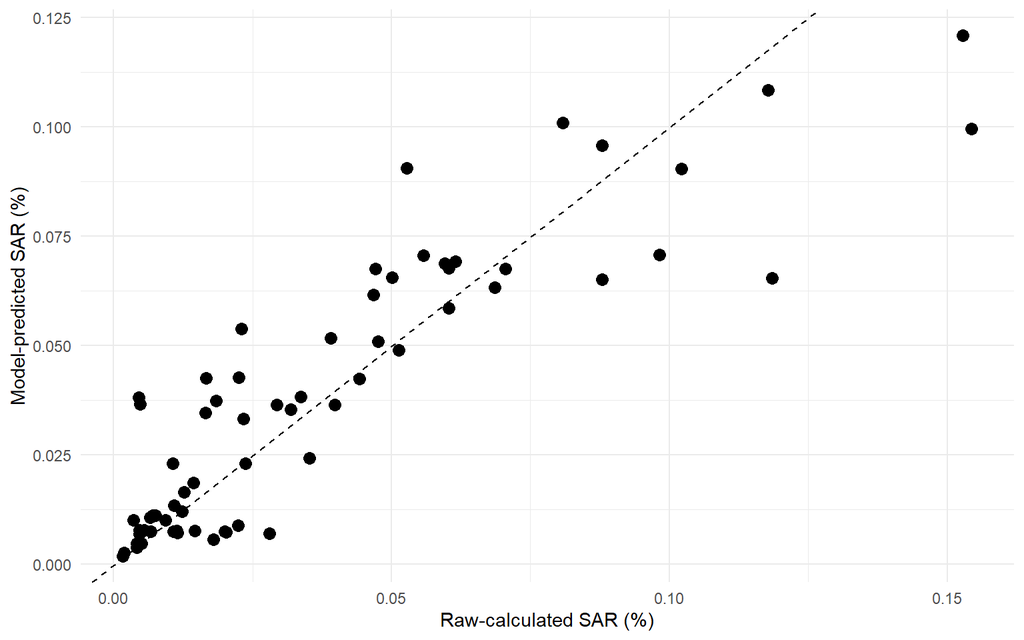

Figure 17: Raw-calculated vs. Model-predicted smolt-adult return generated from the model fit.

**Tab 4**

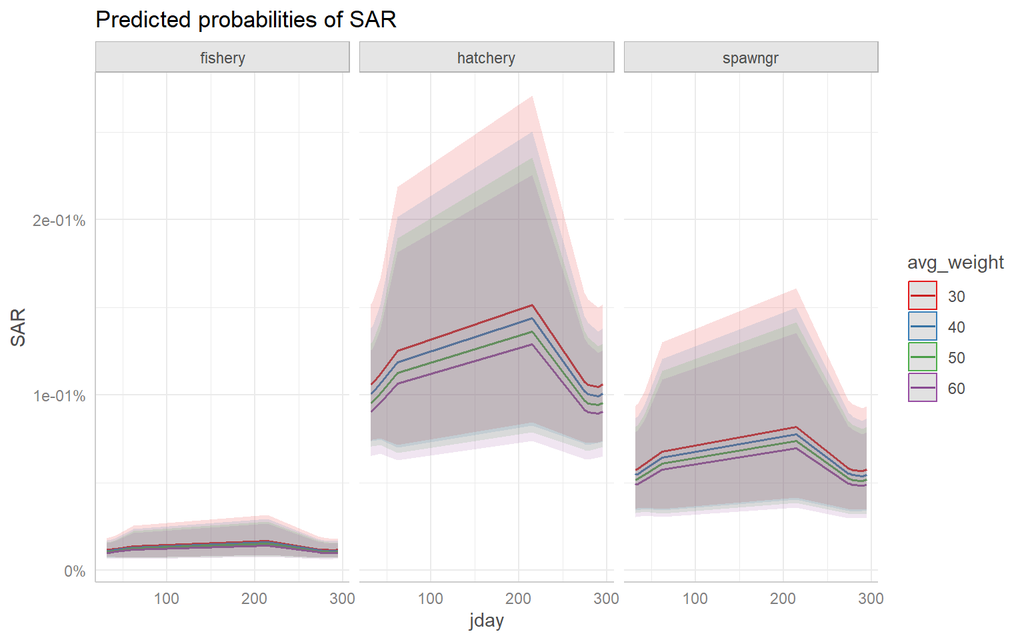

Figure 18: Marginal effects from the model fit showing how combined changes in mean weight at release and release timing (jday) affect smolt-adult-return across fates.

**Tab 1**

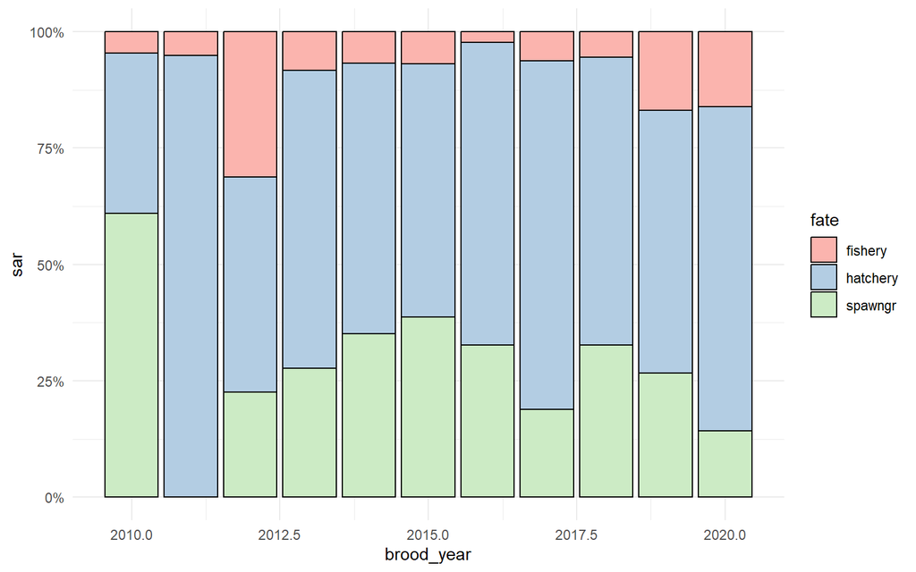

Figure 19: Proportion-at-fate of the calculated smolt-adult-return across brood years.

**Tab 2**

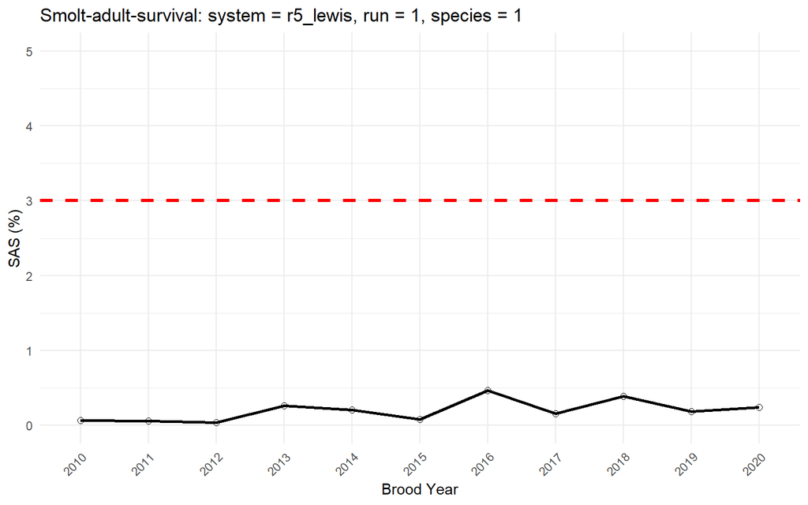

Figure 20: Smolt-adult-survival (SAS) calculated from fate-specific smolt-adult-return relative to a general SAS target for the queried species (red-dashed line).